# Open Meteo Weather Exploration

A boxplot for delta daily precipitation is created:

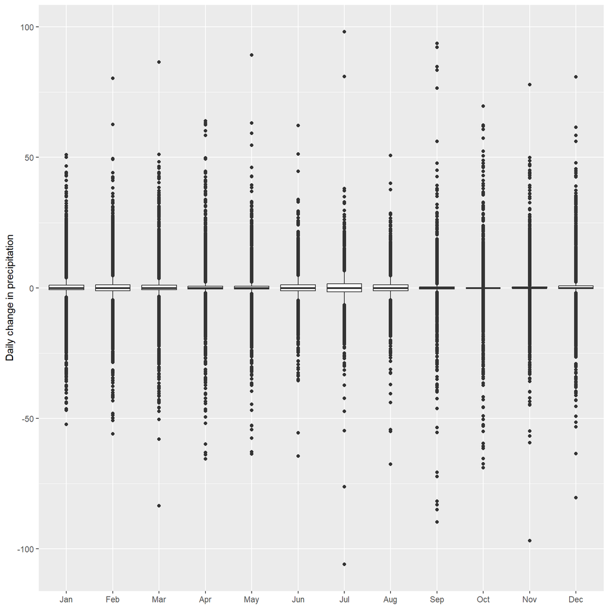

```r
dfDailyATL %>%
    mutate(month=factor(month.abb[month(date)], levels=month.abb),
           chg=precipitation_sum-lag(precipitation_sum)
           ) %>%
    filter(!is.na(chg)) %>%
    ggplot(aes(x=month, y=chg)) +
    geom_boxplot() +
    labs(x=NULL, y="Daily change in precipitation")
```

Averages for temperature, precipitation, and wind speed are calculated by day of year, using a 21-day rolling window:

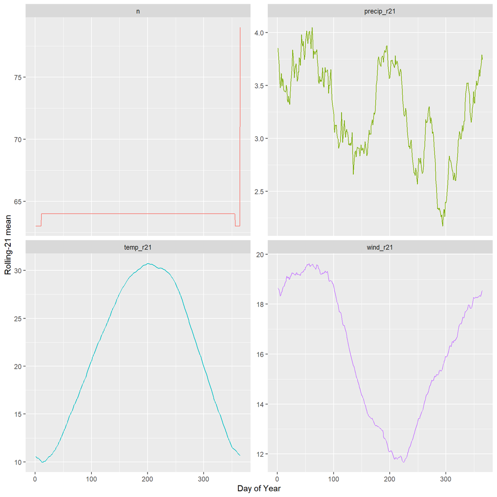

```r
df_r21 <- dfDailyATL %>%
    mutate(doy=pmin(yday(date), 365)) %>%
    helperRollingAgg(origVar="temperature_2m_max", newName="temp_r21", k=21) %>%
    helperRollingAgg(origVar="windspeed_10m_max", newName="wind_r21", k=21) %>%
    helperRollingAgg(origVar="precipitation_sum", newName="precip_r21", k=21) %>%
    select(date, doy, contains("_r21"))

df_r21 %>%
    na.omit() %>%
    group_by(doy) %>%
    summarize(across(where(is.numeric), .fns=mean), n=n()) %>%
    pivot_longer(cols=-c(doy)) %>%
    ggplot(aes(x=doy, y=value)) +
    geom_line(aes(group=name, color=name)) +
    facet_wrap(~name, scales="free_y") +
    labs(x="Day of Year", y="Rolling-21 mean") +
    theme(legend.position="none")
```

- The number of observations is lowest on days 1-10 and 356-365 due to inability to get a rolling-21 for the first/last years; and it is highest on day 365 due to day 366 being mapped there
- Precipitation has seasonal patterns, though it is spiky even on a rolling-21-day basis averaged over 60 years
- Temperature, on average with a 21-day window over 60 years, has a smooth seasonal pattern
- Wind speed is similar to temperature in showing a smooth pattern, though still with occasional spikiness

Outliers are likely much more important in driving average precipitation than in driving average temperature

Standard deviations for temperature, precipitation, and wind speed are calculated by day of year, using a 21-day rolling window:

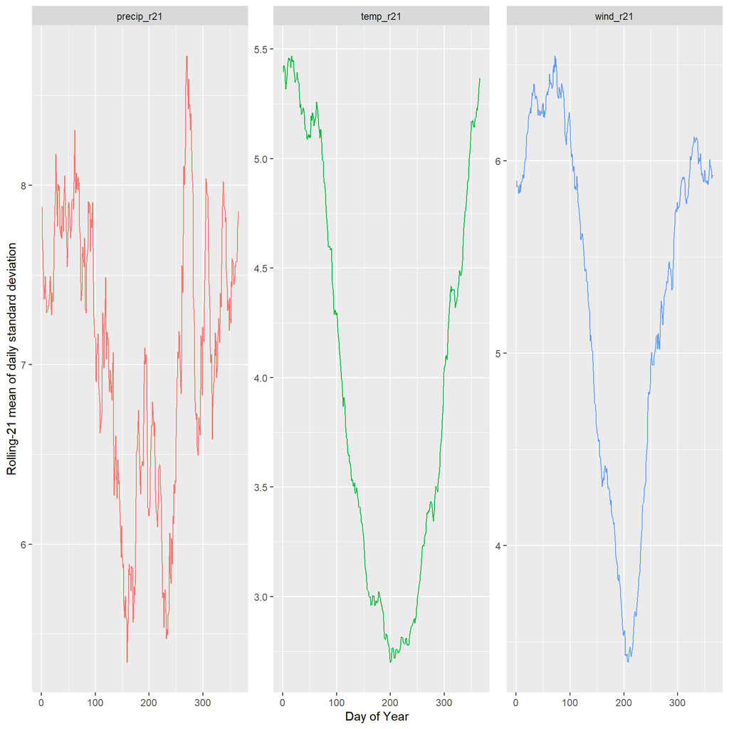

```r
df_r21_sd <- dfDailyATL %>%
    mutate(doy=pmin(yday(date), 365)) %>%
    group_by(doy) %>%
    mutate(across(.cols=c(temperature_2m_max, windspeed_10m_max, precipitation_sum), .fns=sd)) %>%
    ungroup() %>%
    helperRollingAgg(origVar="temperature_2m_max", newName="temp_r21", k=21) %>%
    helperRollingAgg(origVar="windspeed_10m_max", newName="wind_r21", k=21) %>%
    helperRollingAgg(origVar="precipitation_sum", newName="precip_r21", k=21) %>%
    select(date, doy, contains("_r21"))

df_r21_sd %>%
    na.omit() %>%
    group_by(doy) %>%
    summarize(across(where(is.numeric), .fns=mean)) %>%
    pivot_longer(cols=-c(doy)) %>%
    ggplot(aes(x=doy, y=value)) +
    geom_line(aes(group=name, color=name)) +
    facet_wrap(~name, scales="free_y") +
    labs(x="Day of Year", y="Rolling-21 mean of daily standard deviation") +
    theme(legend.position="none")
```

- The daily standard deviation of precipitation is, on average, larger than the mean
- The daily standard deviation of temperature and wind speed are, on average, much lower than the seasonal variation in temperature and wind speed

Means and standard deviations are plotted together:

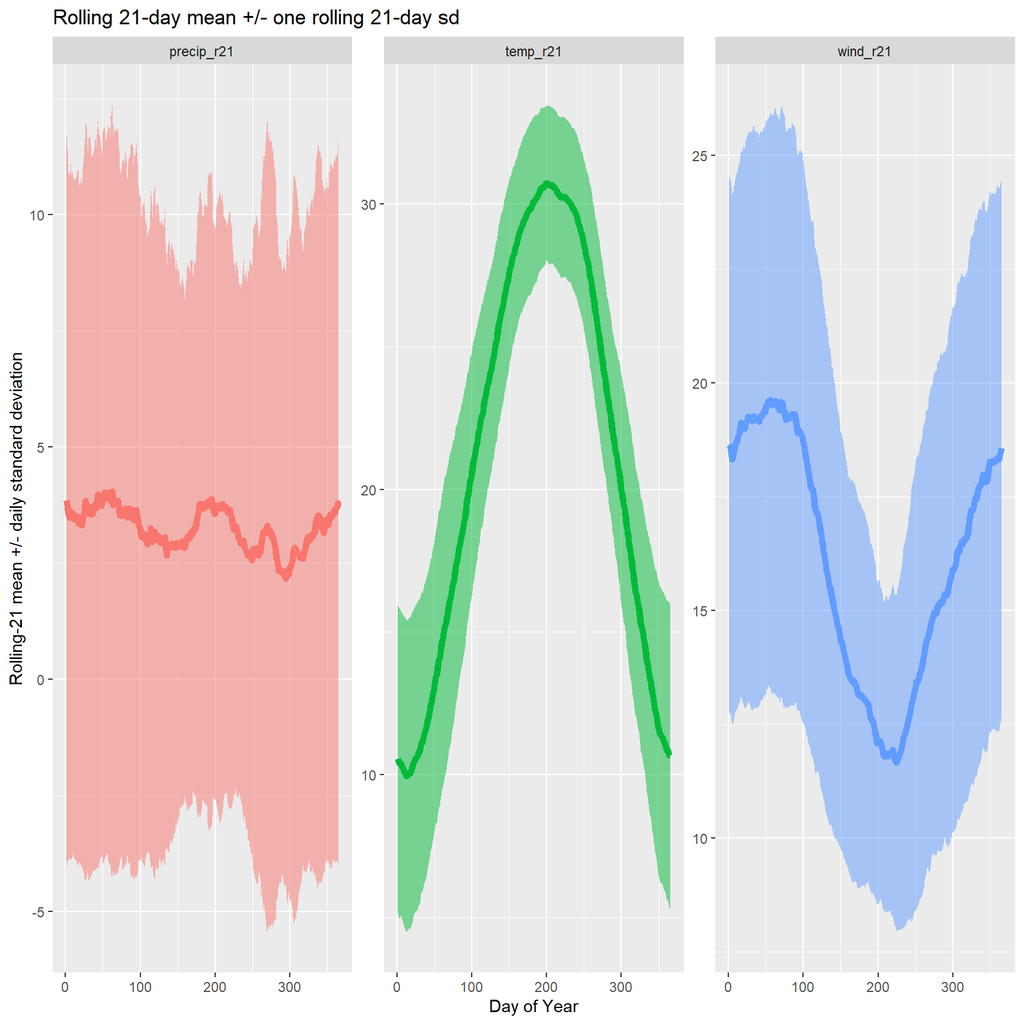

```r
df_r21 %>%
    bind_rows(df_r21_sd, .id="src") %>%
    na.omit() %>%
    mutate(musig=c("1"="Mean", "2"="SD")[src]) %>%
    group_by(doy, musig) %>%
    summarize(across(where(is.numeric), .fns=mean), .groups="drop") %>%
    pivot_longer(cols=-c(doy, musig)) %>%
    pivot_wider(id_cols=c(doy, name), names_from="musig") %>%
    ggplot(aes(x=doy)) +
    geom_line(aes(y=Mean, group=name, color=name), lwd=2) +
    geom_ribbon(aes(ymin=Mean-SD, ymax=Mean+SD, fill=name), alpha=0.5) +
    facet_wrap(~name, scales="free_y") +
    labs(x="Day of Year",
         y="Rolling-21 mean +/- daily standard deviation",
         title="Rolling 21-day mean +/- one rolling 21-day sd"
         ) +
    theme(legend.position="none")
```

Means and approximate SEM are plotted together:

```r
nYears <- length(unique(year(df_r21$date)))
nYears
```

```
## [1] 64
```

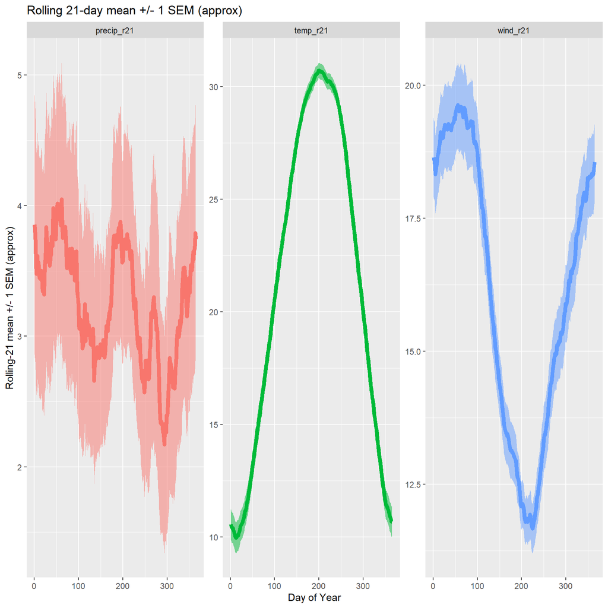

```r
df_r21 %>%
    bind_rows(df_r21_sd, .id="src") %>%
    na.omit() %>%
    mutate(musig=c("1"="Mean", "2"="SD")[src]) %>%
    group_by(doy, musig) %>%
    summarize(across(where(is.numeric), .fns=mean), .groups="drop") %>%
    pivot_longer(cols=-c(doy, musig)) %>%
    pivot_wider(id_cols=c(doy, name), names_from="musig") %>%
    ggplot(aes(x=doy)) +
    geom_line(aes(y=Mean, group=name, color=name), lwd=2) +
    geom_ribbon(aes(ymin=Mean-SD/sqrt(nYears-1), ymax=Mean+SD/sqrt(nYears-1), fill=name), alpha=0.5) +
    facet_wrap(~name, scales="free_y") +
    labs(x="Day of Year",
         y="Rolling-21 mean +/- 1 SEM (approx)",
         title="Rolling 21-day mean +/- 1 SEM (approx)"
         ) +
    theme(legend.position="none")
```

Consistent with previous analyses, temperature has a strong seasonal pattern with differences in mean that vastly exceed the standard error of the mean. By contrast, while there is apparent seasonal spikiness to precipitation, rolling 21-day means are usually within one standard error of the mean of each other. Wind is more similar to temperature in having seasonal variations that meaningfully exceed SEM in magnitude.

Percentage of cumulative precipitation by volume of daily precipitation is explored:

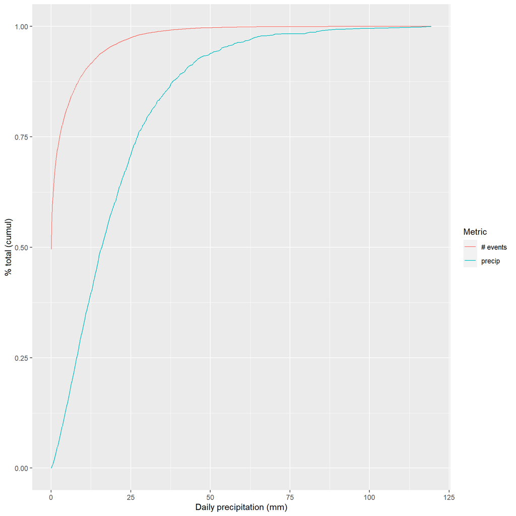

```r
tmpPlotData <- dfDailyATL %>%
    select(date, precipitation_sum) %>%
    group_by(precipitation_sum) %>%
    summarize(n=n(), precip=sum(precipitation_sum), .groups="drop") %>%
    mutate(csp=cumsum(precip), cpp=csp/sum(precip), csn=cumsum(n), cpn=csn/sum(n))

tmpPlotData %>%
    pivot_longer(cols=-c(precipitation_sum)) %>%
    ggplot(aes(x=precipitation_sum, y=value)) +
    geom_line(data=~filter(., name %in% c("cpp", "cpn")),
              aes(group=name, color=c("cpn"="# events", "cpp"="precip")[name])
              ) +
    labs(x="Daily precipitation (mm)", y="% total (cumul)") +
    scale_color_discrete("Metric")
```

Around half of days have no precipitation. Around 25% of total precipitation comes from the rare day with 25+ mm (about an inch) of precipitation

Total precipitation by decade is also explored, sorted by daily precipitation:

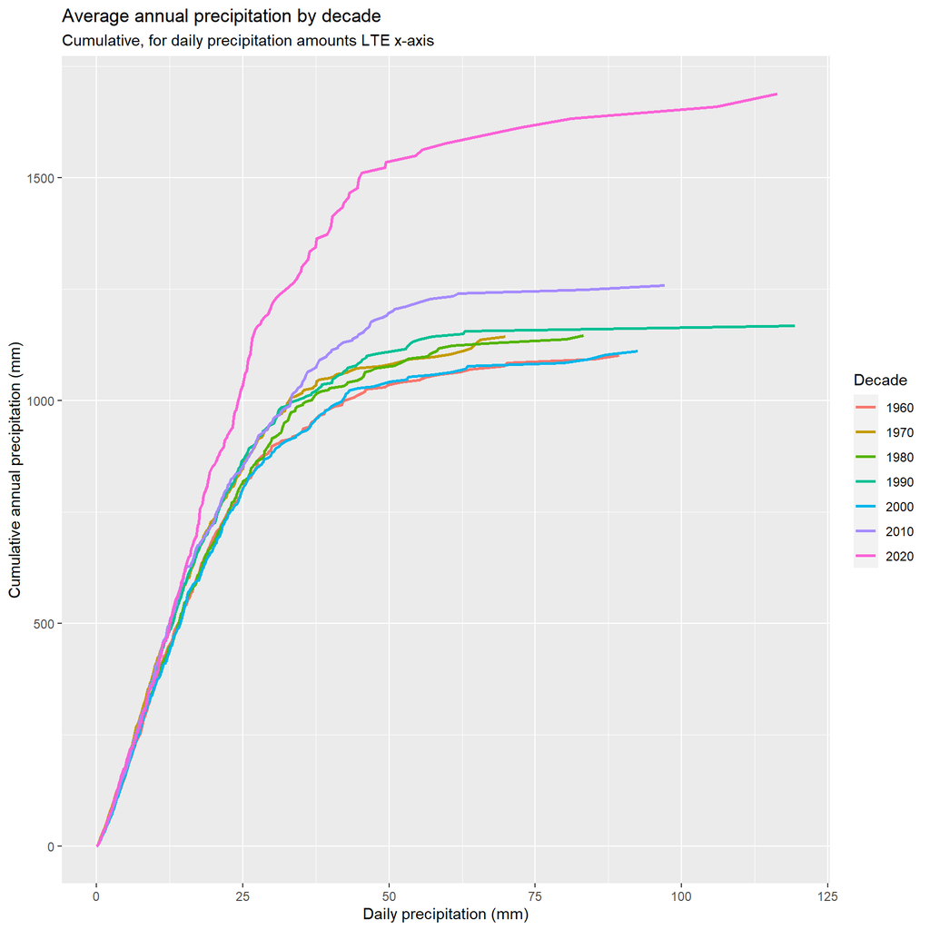

```r
dfDailyATL %>%
    select(date, precipitation_sum) %>%
    mutate(year=year(date), decade=round(year(date)-4.5, -1)) %>%
    group_by(decade, precipitation_sum) %>%
    summarize(n=n(), precip=sum(precipitation_sum), .groups="drop") %>%
    group_by(decade) %>%
    mutate(csp=cumsum(precip), ntot=sum(n), meancsp=365*csp/ntot) %>%
    ungroup() %>%
    ggplot(aes(x=precipitation_sum, y=meancsp)) +
    geom_line(aes(group=factor(decade), color=factor(decade)), lwd=1) +
    labs(x="Daily precipitation (mm)",
         y="Cumulative annual precipitation (mm)",
         title="Average annual precipitation by decade",
         subtitle="Cumulative, for daily precipitation amounts LTE x-axis"
         ) +
    scale_color_discrete("Decade")
```

Trends look similar by decade for precipitation amounts under 0.5 inch (12.5 mm). Heavier precipitation amounts appear to be more prevalent in the 202s, driving overall precipitation totals ~50% higher

Precipitation appears to have broken trend starting in the late 2010s:

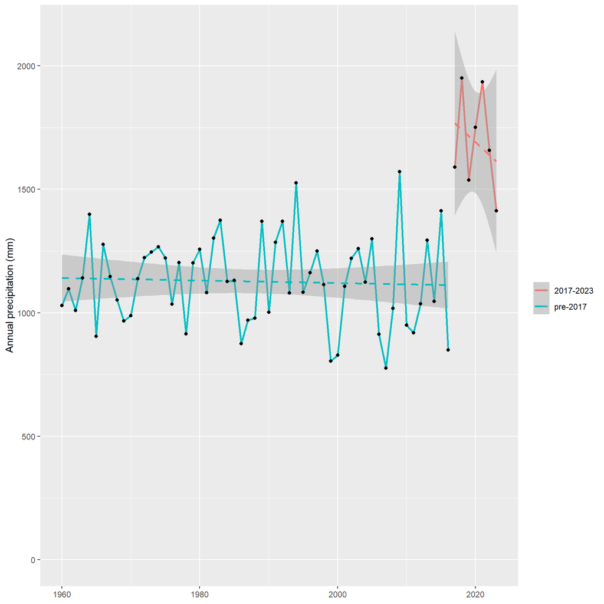

```r
dfDailyATL %>%
    select(date, precipitation_sum) %>%
    mutate(year=year(date), decade=round(year(date)-4.5, -1)) %>%
    group_by(decade, year) %>%
    summarize(precip=sum(precipitation_sum), .groups="drop") %>%
    ggplot(aes(x=year, y=precip)) +
    geom_line(aes(color=ifelse(year>=2017, "2017-2023", "pre-2017")), lwd=1) +
    geom_smooth(aes(color=ifelse(year>=2017, "2017-2023", "pre-2017")), method="lm", lty=2) +
    geom_point() +
    labs(x=NULL, y="Annual precipitation (mm)") +
    scale_color_discrete(NULL) +
    lims(y=c(0, NA))
```

Precipitation by month pre-2017 is explored:

```r
yMax <- dfDailyATL %>%
    group_by(year=year(date), month=month(date)) %>%
    summarize(precip=sum(precipitation_sum), .groups="drop") %>%
    mutate(precip=ceiling(precip/50)*50) %>%
    pull() %>%
    max()
yMax
```

```
## [1] 350
```

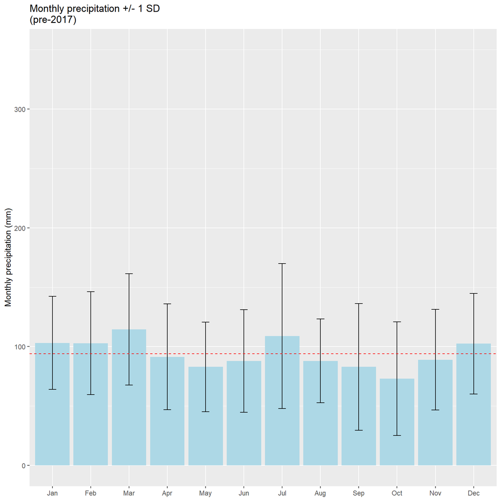

```r
p1 <- dfDailyATL %>%
    select(date, precipitation_sum) %>%
    mutate(year=year(date),
           decade=round(year(date)-4.5, -1),
           month=factor(month.abb[month(date)], levels=month.abb),
           tp=ifelse(year<2017, "pre", year)
           ) %>%
    group_by(tp, year, month) %>%
    summarize(precip=sum(precipitation_sum), .groups="drop") %>%
    group_by(tp, month) %>%
    summarize(mu=mean(precip), sd=sd(precip), .groups="drop") %>%
    ggplot(aes(x=month)) +
    geom_col(data=~filter(., tp=="pre"), aes(y=mu), fill="lightblue") +
    geom_errorbar(data=~filter(., tp=="pre"), aes(ymin=mu-sd, ymax=mu+sd), width=0.2) +
    geom_hline(data=~filter(., tp=="pre"), color="red", lty=2, aes(yintercept=mean(mu))) +
    labs(x=NULL, y="Monthly precipitation (mm)", title="Monthly precipitation +/- 1 SD\n(pre-2017)") +
    lims(y=c(0, yMax))
p1
```

Precipitation by month post-2017 is explored:

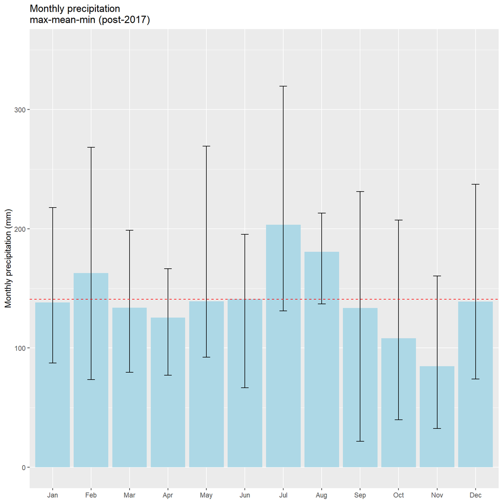

```r
p2 <- dfDailyATL %>%
    select(date, precipitation_sum) %>%
    mutate(year=year(date),
           decade=round(year(date)-4.5, -1),
           month=factor(month.abb[month(date)], levels=month.abb),
           tp=ifelse(year<2017, "pre", year)
           ) %>%
    group_by(tp, year, month) %>%
    summarize(precip=sum(precipitation_sum), .groups="drop") %>%
    filter(tp!="pre") %>%
    group_by(month) %>%
    summarize(mu=mean(precip), mx=max(precip), mn=min(precip), .groups="drop") %>%
    ggplot(aes(x=month)) +
    geom_col(aes(y=mu), fill="lightblue") +
    geom_errorbar(aes(ymin=mn, ymax=mx), width=0.2) +
    geom_hline(color="red", lty=2, aes(yintercept=mean(mu))) +
    labs(x=NULL, y="Monthly precipitation (mm)", title="Monthly precipitation\nmax-mean-min (post-2017)") +
    lims(y=c(0, yMax))
p2
```

The data are plotted on a single plot:

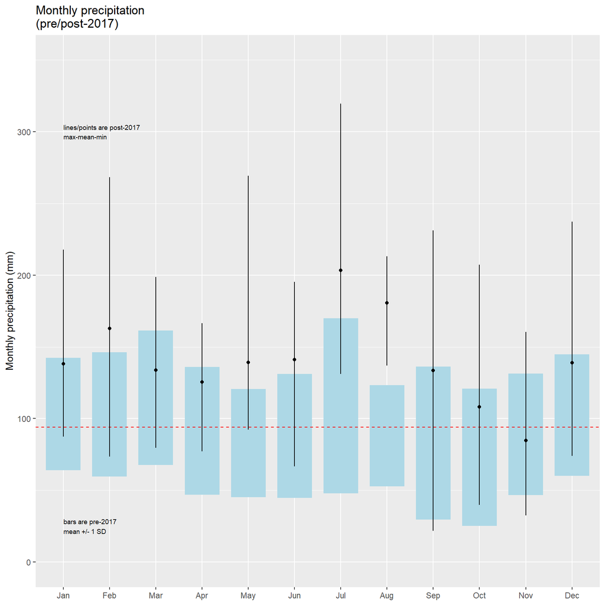

```r
p3 <- dfDailyATL %>%
    select(date, precipitation_sum) %>%
    mutate(year=year(date),
           decade=round(year(date)-4.5, -1),
           month=factor(month.abb[month(date)], levels=month.abb),
           tp=ifelse(year<2017, "pre", "post")
    ) %>%
    group_by(tp, year, month) %>%
    summarize(precip=sum(precipitation_sum), .groups="drop") %>%
    group_by(tp, month) %>%
    summarize(mu=mean(precip), sd=sd(precip), mx=max(precip), mn=min(precip), .groups="drop") %>%
    ggplot(aes(x=month)) +
    geom_tile(data=~filter(., tp=="pre"), aes(y=mu, height=2*sd), width=0.75, fill="lightblue") +
    geom_hline(data=~filter(., tp=="pre"), color="red", lty=2, aes(yintercept=mean(mu))) +
    geom_errorbar(data=~filter(., tp=="post"), aes(ymin=mn, ymax=mx), width=0) +
    geom_point(data=~filter(., tp=="post"), aes(y=mu)) +
    annotate("text", x=1, y=25, label="bars are pre-2017\nmean +/- 1 SD", size=2.5, hjust=0) +
    annotate("text", x=1, y=300, label="lines/points are post-2017\nmax-mean-min", size=2.5, hjust=0) +
    labs(x=NULL, y="Monthly precipitation (mm)", title="Monthly precipitation\n(pre/post-2017)") +
    lims(y=c(0, yMax))
p3
```

The average number of days with precipitation by month is explored:

```r
yMax <- dfDailyATL %>%
    group_by(year=year(date), month=month(date)) %>%
    summarize(precip=sum(precipitation_sum>0), .groups="drop") %>%
    mutate(precip=ceiling(precip/5)*5) %>%
    pull() %>%
    max()
yMax
```

```
## [1] 35
```

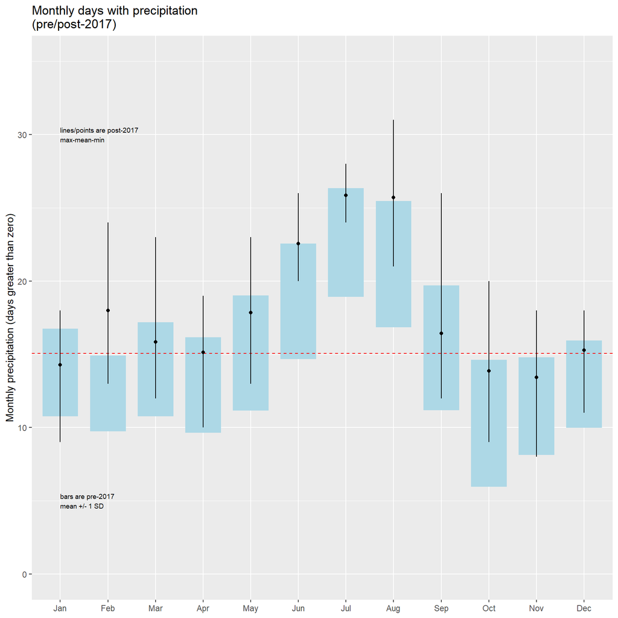

```r
p4 <- dfDailyATL %>%
    select(date, precipitation_sum) %>%
    mutate(year=year(date),
           decade=round(year(date)-4.5, -1),
           month=factor(month.abb[month(date)], levels=month.abb),
           tp=ifelse(year<2017, "pre", "post")
    ) %>%
    group_by(tp, year, month) %>%
    summarize(precip=sum(precipitation_sum>0), .groups="drop") %>%
    group_by(tp, month) %>%
    summarize(mu=mean(precip), sd=sd(precip), mx=max(precip), mn=min(precip), .groups="drop") %>%
    ggplot(aes(x=month)) +
    geom_tile(data=~filter(., tp=="pre"), aes(y=mu, height=2*sd), width=0.75, fill="lightblue") +
    geom_hline(data=~filter(., tp=="pre"), color="red", lty=2, aes(yintercept=mean(mu))) +
    geom_errorbar(data=~filter(., tp=="post"), aes(ymin=mn, ymax=mx), width=0) +
    geom_point(data=~filter(., tp=="post"), aes(y=mu)) +
    annotate("text", x=1, y=5, label="bars are pre-2017\nmean +/- 1 SD", size=2.5, hjust=0) +
    annotate("text", x=1, y=30, label="lines/points are post-2017\nmax-mean-min", size=2.5, hjust=0) +
    labs(x=NULL,
         y="Monthly precipitation (days greater than zero)",
         title="Monthly days with precipitation\n(pre/post-2017)") +
    lims(y=c(0, yMax))
p4
```

Median precipitation on days with precipitation > 0, by month, is explored:

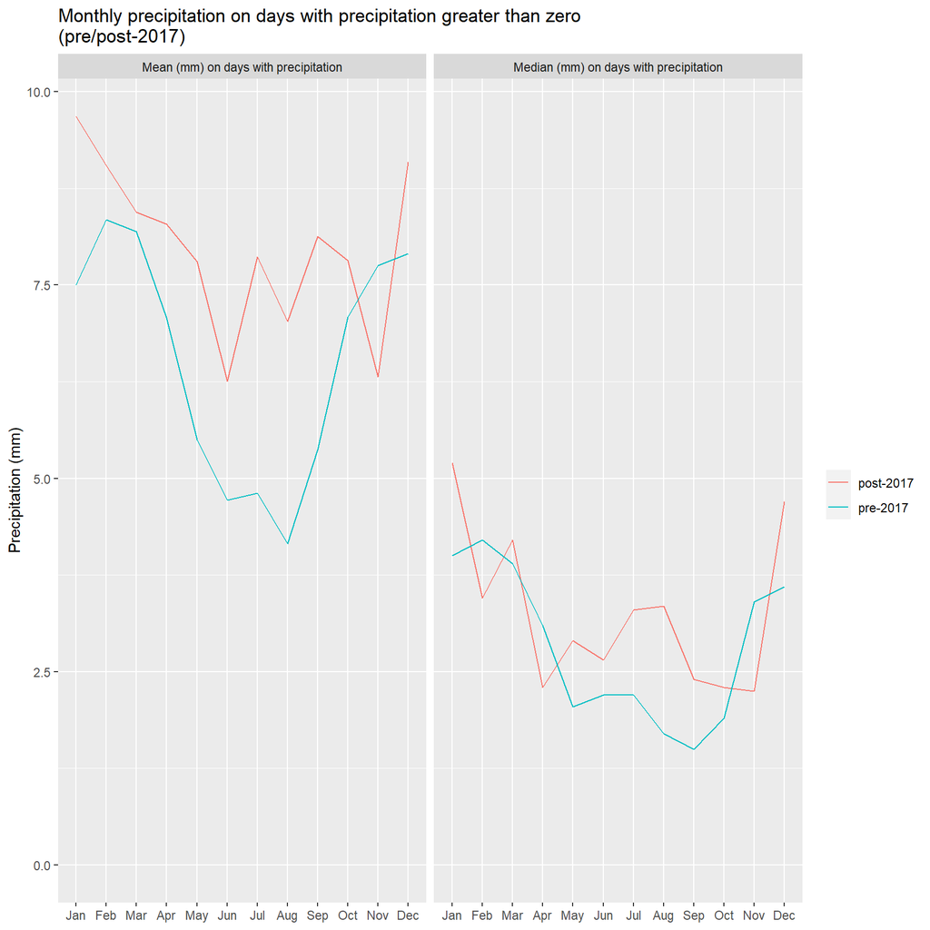

```r
p5 <- dfDailyATL %>%
    select(date, precipitation_sum) %>%
    mutate(year=year(date),
           decade=round(year(date)-4.5, -1),
           month=factor(month.abb[month(date)], levels=month.abb),
           tp=ifelse(year<2017, "pre", "post")
    ) %>%
    group_by(tp, month) %>%
    summarize(nprecip=sum(precipitation_sum>0),
              tprecip=sum(precipitation_sum),
              mdnprecip=median(ifelse(precipitation_sum>0, precipitation_sum, NA), na.rm=TRUE),
              muprecip=mean(ifelse(precipitation_sum>0, precipitation_sum, NA), na.rm=TRUE),
              .groups="drop"
              ) %>%
    select(tp, month, mdnprecip, muprecip) %>%
    pivot_longer(-c(tp, month)) %>%
    ggplot(aes(x=month)) +
    geom_line(aes(y=value, group=tp, color=c("pre"="pre-2017", "post"="post-2017")[tp])) +
    facet_wrap(~c("mdnprecip"="Median (mm) on days with precipitation",
                  "muprecip"="Mean (mm) on days with precipitation"
                  )[name]
               ) +
    labs(x=NULL,
         title="Monthly precipitation on days with precipitation greater than zero\n(pre/post-2017)",
         y="Precipitation (mm)"
         ) +
    ylim(c(0, NA)) +
    scale_color_discrete(NULL)
p5
```

The heaviest 3-day precipitation by year is explored:

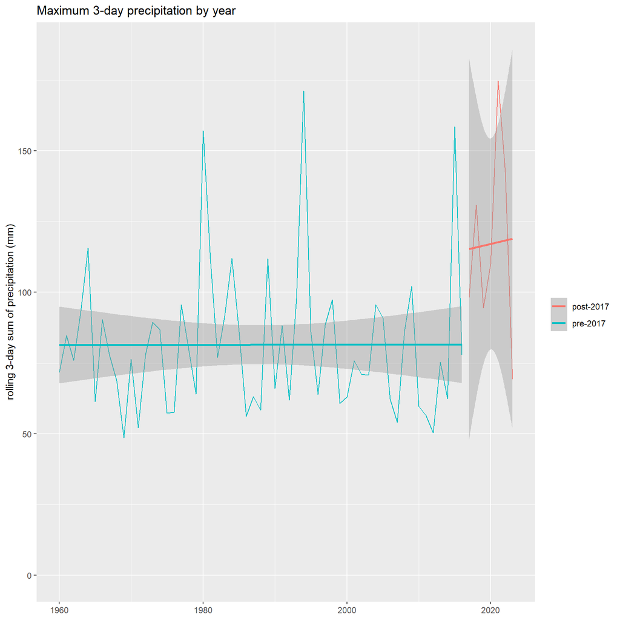

```r
p6 <- dfDailyATL %>%
    select(date, precipitation_sum) %>%
    mutate(year=year(date),
           decade=round(year(date)-4.5, -1),
           month=factor(month.abb[month(date)], levels=month.abb),
           tp=ifelse(year<2017, "pre", "post")
    ) %>%
    group_by(tp, year) %>%
    helperRollingAgg(origVar="precipitation_sum", newName="r3precip", func=zoo::rollsum, k=3) %>%
    summarize(r3max=max(r3precip, na.rm=TRUE), .groups="drop") %>%
    ggplot(aes(x=year)) +
    geom_line(aes(y=r3max, group=tp, color=c("pre"="pre-2017", "post"="post-2017")[tp])) +
    labs(x=NULL,
         title="Maximum 3-day precipitation by year",
         y="rolling 3-day sum of precipitation (mm)"
         ) +
    geom_smooth(method="lm",
                se=TRUE,
                aes(y=r3max, group=tp, color=c("pre"="pre-2017", "post"="post-2017")[tp])
                ) +
    ylim(c(0, NA)) +
    scale_color_discrete(NULL)
p6
```

Long term daily data is downloaded for Detroit:

```r
# Daily data download for Detroit, MI
testURLDaily <- helperOpenMeteoURL(cityName="Detroit MI",
                                   dailyIndices=1:nrow(tblMetricsDaily),
                                   startDate="1960-01-01",
                                   endDate="2023-12-31",
                                   tz="US/Eastern"
                                   )
```

```
##
## Daily metrics created from indices: weathercode,temperature_2m_max,temperature_2m_min,apparent_temperature_max,apparent_temperature_min,precipitation_sum,rain_sum,snowfall_sum,precipitation_hours,sunrise,sunset,windspeed_10m_max,windgusts_10m_max,winddirection_10m_dominant,shortwave_radiation_sum…
```

```r
testURLDaily
```

```
## [1] "https://archive-api.open-meteo.com/v1/archive?latitude=42.38&longitude=-83.1&start_date=1960-01-01&end_date=2023-12-31&daily=weathercode,temperature_2m_max,temperature_2m_min,apparent_temperature_max,apparent_temperature_min,precipitation_sum,rain_sum,snowfall_sum,precipitation_hours,sunrise…
```

```r
# Download file
if(!file.exists("testOM_daily_dtw.json")) {
    fileDownload(fileName="testOM_daily_dtw.json", url=testURLDaily)
} else {
    cat("\nFile testOM_daily_dtw.json already exists, skipping download\n")
}
```

```
##
## File testOM_daily_dtw.json already exists, skipping download
```

The daily dataset is loaded:

```r
# Read daily JSON file
dtwOMDaily <- formatOpenMeteoJSON("testOM_daily_dtw.json")
```

```
##
## Objects in JSON include: latitude, longitude, generationtime_ms, utc_offset_seconds, timezone, timezone_abbreviation, elevation, daily_units, daily
##
## $tblDaily
## # A tibble: 23,376 × 18
##    date       time       weathercode temperature_2m_max temperature_2m_min
##    <date>     <chr>            <int>              <dbl>              <dbl>
##  1 1960-01-01 1960-01-01           3                0.4               -4.4
##  2 1960-01-02 1960-01-02          55                3.2               -2.5
##  3 1960-01-03 1960-01-03          51                2.7               -2.9
##  4 1960-01-04 1960-01-04           3               -3.3               -8.4
##  5 1960-01-05 1960-01-05           3               -6                 -9.7
##  6 1960-01-06 1960-01-06           3               -0.8              -10.7
##  7 1960-01-07 1960-01-07           3                4.1               -4.9
##  8 1960-01-08 1960-01-08          51                2.5               -6.7
##  9 1960-01-09 1960-01-09          51                1.8               -7.3
## 10 1960-01-10 1960-01-10          51                4.7               -2
## # ℹ 23,366 more rows
## # ℹ 13 more variables: apparent_temperature_max <dbl>,
## #   apparent_temperature_min <dbl>, precipitation_sum <dbl>, rain_sum <dbl>,
## #   snowfall_sum <dbl>, precipitation_hours <dbl>, sunrise <chr>, sunset <chr>,
## #   windspeed_10m_max <dbl>, windgusts_10m_max <dbl>,
## #   winddirection_10m_dominant <int>, shortwave_radiation_sum <dbl>,
## #   et0_fao_evapotranspiration <dbl>
##
## $tblHourly
## NULL
##
## $tblUnits
## # A tibble: 17 × 4
##    metricType  name                       value      description
##    <chr>       <chr>                      <chr>      <chr>
##  1 daily_units time                       "iso8601"  <NA>
##  2 daily_units weathercode                "wmo code" The most severe weather co…
##  3 daily_units temperature_2m_max         "deg C"    Maximum and minimum daily …
##  4 daily_units temperature_2m_min         "deg C"    Maximum and minimum daily …
##  5 daily_units apparent_temperature_max   "deg C"    Maximum and minimum daily …
##  6 daily_units apparent_temperature_min   "deg C"    Maximum and minimum daily …
##  7 daily_units precipitation_sum          "mm"       Sum of daily precipitation…
##  8 daily_units rain_sum                   "mm"       Sum of daily rain
```

[output cut: 10 more lines]

```
## $tblDescription
## # A tibble: 1 × 7
##   latitude longitude generationtime_ms utc_offset_seconds timezone
##      <dbl>     <dbl>             <dbl>              <int> <chr>
## 1     42.4     -83.1              372.             -18000 US/Eastern
## # ℹ 2 more variables: timezone_abbreviation <chr>, elevation <dbl>
##
##
## latitude: 42.35501
## longitude: -83.13785
## generationtime_ms: 371.5783
## utc_offset_seconds: -18000
## timezone: US/Eastern
## timezone_abbreviation: GMT-5
## elevation: 199
```

```r
# Sample records of tibble
dtwOMDaily$tblDaily %>% glimpse()
```

```
## Rows: 23,376
## Columns: 18
## $ date                       <date> 1960-01-01, 1960-01-02, 1960-01-03, 1960-0…
## $ time                       <chr> "1960-01-01", "1960-01-02", "1960-01-03", "…
## $ weathercode                <int> 3, 55, 51, 3, 3, 3, 3, 51, 51, 51, 3, 63, 6…
## $ temperature_2m_max         <dbl> 0.4, 3.2, 2.7, -3.3, -6.0, -0.8, 4.1, 2.5, …
## $ temperature_2m_min         <dbl> -4.4, -2.5, -2.9, -8.4, -9.7, -10.7, -4.9, …
## $ apparent_temperature_max   <dbl> -4.4, -1.1, -1.8, -9.2, -13.1, -7.0, -3.1, …
## $ apparent_temperature_min   <dbl> -8.1, -7.4, -8.9, -14.9, -15.2, -18.0, -9.6…
## $ precipitation_sum          <dbl> 0.0, 7.6, 0.4, 0.0, 0.0, 0.0, 0.0, 0.4, 0.3…
## $ rain_sum                   <dbl> 0.0, 7.6, 0.4, 0.0, 0.0, 0.0, 0.0, 0.4, 0.3…
## $ snowfall_sum               <dbl> 0.00, 0.00, 0.00, 0.00, 0.00, 0.00, 0.00, 0…
## $ precipitation_hours        <dbl> 0, 17, 4, 0, 0, 0, 0, 4, 3, 1, 0, 17, 6, 4,…
## $ sunrise                    <chr> "1960-01-01T08:01", "1960-01-02T08:01", "19…
## $ sunset                     <chr> "1960-01-01T17:10", "1960-01-02T17:10", "19…
## $ windspeed_10m_max          <dbl> 15.0, 21.5, 25.6, 23.0, 28.7, 30.3, 30.9, 3…
## $ windgusts_10m_max          <dbl> 30.2, 42.5, 48.2, 45.0, 54.4, 54.4, 57.6, 6…
## $ winddirection_10m_dominant <int> 109, 196, 261, 247, 257, 239, 223, 272, 161…
## $ shortwave_radiation_sum    <dbl> 6.09, 0.93, 4.91, 4.91, 8.07, 6.47, 4.41, 6…
## $ et0_fao_evapotranspiration <dbl> 0.55, 0.33, 0.81, 0.96, 1.04, 1.07, 1.01, 1…
```

Variables are converted to proper data type:

```r
dfDailyDTW <- dtwOMDaily$tblDaily %>%
    mutate(weathercode=factor(weathercode),
           sunrise_chr=sunrise,
           sunset_chr=sunset,
           sunrise=lubridate::ymd_hm(sunrise),
           sunset=lubridate::ymd_hm(sunset),
           fct_winddir=factor(winddirection_10m_dominant)
           )
glimpse(dfDailyDTW)
```

```
## Rows: 23,376
## Columns: 21
## $ date                       <date> 1960-01-01, 1960-01-02, 1960-01-03, 1960-0…
## $ time                       <chr> "1960-01-01", "1960-01-02", "1960-01-03", "…
## $ weathercode                <fct> 3, 55, 51, 3, 3, 3, 3, 51, 51, 51, 3, 63, 6…
## $ temperature_2m_max         <dbl> 0.4, 3.2, 2.7, -3.3, -6.0, -0.8, 4.1, 2.5, …
## $ temperature_2m_min         <dbl> -4.4, -2.5, -2.9, -8.4, -9.7, -10.7, -4.9, …
## $ apparent_temperature_max   <dbl> -4.4, -1.1, -1.8, -9.2, -13.1, -7.0, -3.1, …
## $ apparent_temperature_min   <dbl> -8.1, -7.4, -8.9, -14.9, -15.2, -18.0, -9.6…
## $ precipitation_sum          <dbl> 0.0, 7.6, 0.4, 0.0, 0.0, 0.0, 0.0, 0.4, 0.3…
## $ rain_sum                   <dbl> 0.0, 7.6, 0.4, 0.0, 0.0, 0.0, 0.0, 0.4, 0.3…
## $ snowfall_sum               <dbl> 0.00, 0.00, 0.00, 0.00, 0.00, 0.00, 0.00, 0…
## $ precipitation_hours        <dbl> 0, 17, 4, 0, 0, 0, 0, 4, 3, 1, 0, 17, 6, 4,…
## $ sunrise                    <dttm> 1960-01-01 08:01:00, 1960-01-02 08:01:00, …
## $ sunset                     <dttm> 1960-01-01 17:10:00, 1960-01-02 17:10:00, …
## $ windspeed_10m_max          <dbl> 15.0, 21.5, 25.6, 23.0, 28.7, 30.3, 30.9, 3…
## $ windgusts_10m_max          <dbl> 30.2, 42.5, 48.2, 45.0, 54.4, 54.4, 57.6, 6…
## $ winddirection_10m_dominant <int> 109, 196, 261, 247, 257, 239, 223, 272, 161…
## $ shortwave_radiation_sum    <dbl> 6.09, 0.93, 4.91, 4.91, 8.07, 6.47, 4.41, 6…
## $ et0_fao_evapotranspiration <dbl> 0.55, 0.33, 0.81, 0.96, 1.04, 1.07, 1.01, 1…
## $ sunrise_chr                <chr> "1960-01-01T08:01", "1960-01-02T08:01", "19…
## $ sunset_chr                 <chr> "1960-01-01T17:10", "1960-01-02T17:10", "19…
## $ fct_winddir                <fct> 109, 196, 261, 247, 257, 239, 223, 272, 161…
```

Averages by month for select continuous variables are plotted:

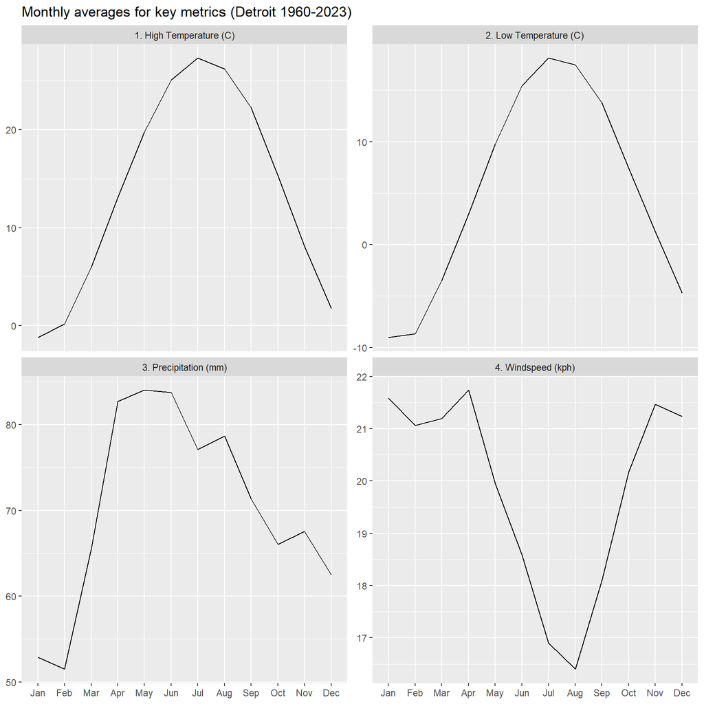

```r
tmpMapNames <- c("precipitation_sum"="3. Precipitation (mm)",
                 "windspeed_10m_max"="4. Windspeed (kph)",
                 "temperature_2m_max"="1. High Temperature (C)",
                 "temperature_2m_min"="2. Low Temperature (C)"
                 )

dfDailyDTW %>%
    mutate(month=factor(month(date), levels=1:12, labels=month.abb), year=year(date)) %>%
    select(year, month, temperature_2m_max, temperature_2m_min, precipitation_sum, windspeed_10m_max) %>%
    group_by(year, month) %>%
    summarize(across(-c(precipitation_sum), .fns=mean),
              across(c(precipitation_sum), .fns=sum),
              .groups="drop"
              ) %>%
    group_by(month) %>%
    summarize(across(-c(year), .fns=mean)) %>%
    pivot_longer(-c(month)) %>%
    ggplot(aes(x=month, y=value)) +
    geom_line(aes(group=1)) +
    facet_wrap(~tmpMapNames[name], scales="free_y") +
    labs(x=NULL, y=NULL, title="Monthly averages for key metrics (Detroit 1960-2023)")
```

Averages by month for select categorical variables are plotted:

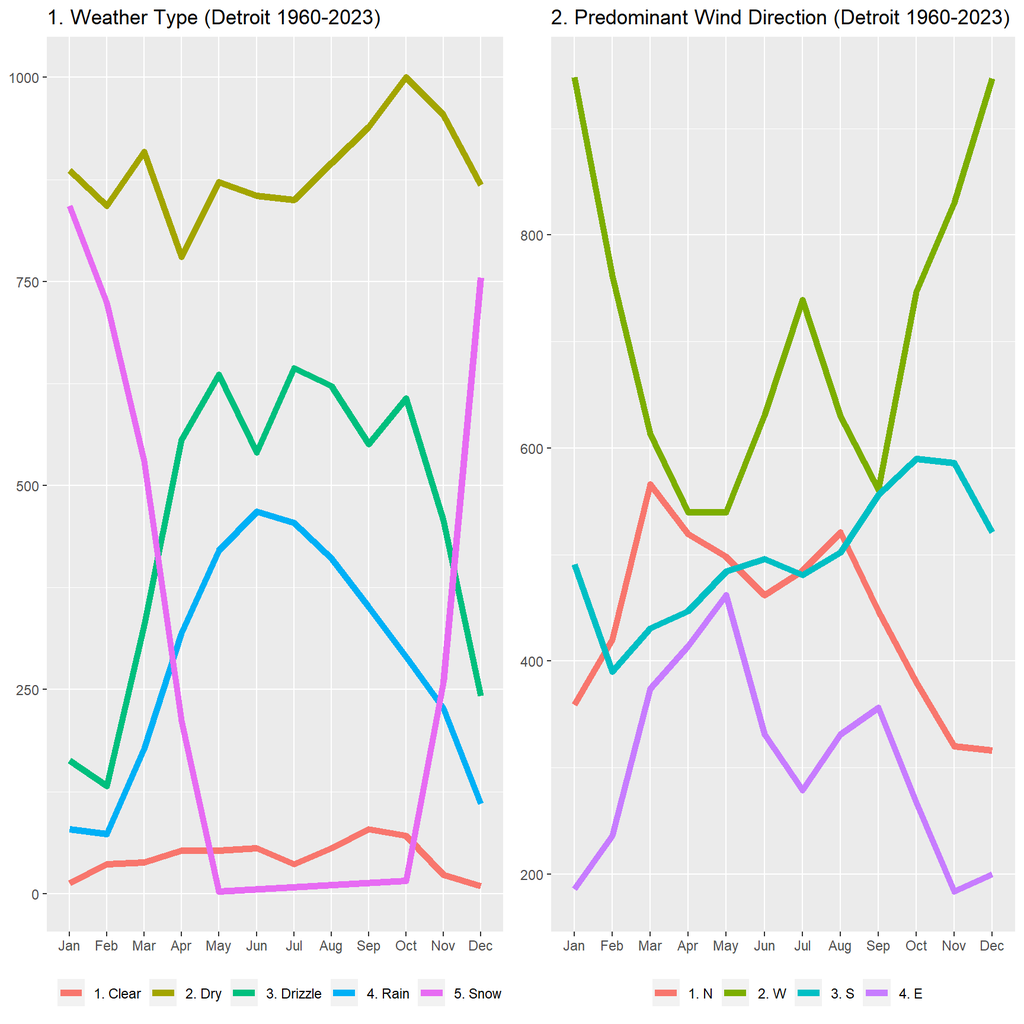

```r
tmpMapNames <- c("wc"="1. Weather Type",
                 "winddir"="2. Predominant Wind Direction"
                 )

tmpDFPlot <- dfDailyDTW %>%
    mutate(month=factor(month(date), levels=1:12, labels=month.abb),
           year=year(date),
           winddir=case_when(winddirection_10m_dominant>360~"Invalid",
                             winddirection_10m_dominant>=315~"1. N",
                             winddirection_10m_dominant>=225~"2. W",
                             winddirection_10m_dominant>=135~"3. S",
                             winddirection_10m_dominant>=45~"4. E",
                             winddirection_10m_dominant>=0~"1. N",
                             TRUE~"Invalid"
                             ),
           wc=case_when(weathercode==0~"1. Clear",
                        weathercode %in% c(1, 2, 3)~"2. Dry",
                        weathercode %in% c(51, 53, 55)~"3. Drizzle",
                        weathercode %in% c(61, 63, 65)~"4. Rain",
                        weathercode %in% c(71, 73, 75)~"5. Snow",
                        TRUE~"Error"
                        )
           ) %>%
    select(month, wc, winddir) %>%
    pivot_longer(-c(month)) %>%
    count(month, name, value)

tmpPlotFN <- function(x) {
    p1 <- tmpDFPlot %>%
        filter(name==x) %>%
        ggplot(aes(x=month, y=n)) +
        geom_line(aes(group=value, color=value), lwd=2) +
        labs(x=NULL,
             y=NULL,
             title=paste0(tmpMapNames[x], " (Detroit 1960-2023)")
             ) +
        scale_color_discrete(NULL) +
        theme(legend.position = "bottom")
    return(p1)
    }

gridExtra::grid.arrange(tmpPlotFN("wc"), tmpPlotFN("winddir"), nrow=1)
```